# Lecture: More on SAS Procedures

### General Comments

- There is an application called Jupyter notebooks (formerly iPython), that has some functionality similar to R Markdown and can execute SAS code. However, it is still very glitchy for SAS and not worth the hassle in this class.
- Manually Entering Data can also be challenging in SAS, next is a similar example to what you worked on in lab.

```sas
* Manual Input of Data;
DATA Favorites;
    INPUT Names $ Food $ Activity $;
        DATALINES;
    Andy Milkshakes Golf
    Eleanor Cauliflower Skiing
    Georgiana Anything Gymnastics
        ;
RUN;

PROC PRINT DATA=Favorites;
RUN;
```

The SAS System

| Obs | Names | Food | Activity |
| --- | --- | --- | --- |
| 1 | Andy | Milkshak | Golf |
| 2 | Eleanor | Cauliflo | Skiing |
| 3 | Georgian | Anything | Gymnasti |

```sas
* Manual Input of Data;
DATA Favorites;
    INPUT Names :$15. Food :$15. Activity :$15.;
        DATALINES;
    Andy Milkshakes Golf
    Eleanor Cauliflower Skiing
    Georgiana Anything Gymnastics
        ;
RUN;

PROC PRINT DATA=Favorites;
RUN;
```

The SAS System

| Obs | Names | Food | Activity |
| --- | --- | --- | --- |
| 1 | Andy | Milkshakes | Golf |
| 2 | Eleanor | Cauliflower | Skiing |
| 3 | Georgiana | Anything | Gymnastics |

### Using PROC MEANS

```sas
* SET LIBNAME (Note this is slightly different in SAS OnDemand, use the link we have seen before);
libname mydata '/folders/myfolders/';
```

```
45   ods listing close;ods html5 file=stdout options(bitmap_mode='inline') device=png; ods graphics on / outputfmt=png;
NOTE: Writing HTML5 Body file: STDOUT
46
47   * SET LIBNAME (Note this is slightly different in SAS OnDemand, use the link we have seen before);
48   libname mydata '/folders/myfolders/';
NOTE: Libref MYDATA was successfully assigned as follows:
      Engine:        V9
      Physical Name: /folders/myfolders
49
50   ods html5 close;ods listing;

51
```

```sas
PROC MEANS DATA = mydata.housing;
RUN;
```

The SAS System

The MEANS Procedure

| Variable | N | Mean | Std Dev | Minimum | Maximum |
| --- | --- | --- | --- | --- | --- |
| Living_Sq_Ft Closing_Price | 2000 2000 | 1840.32 244146.72 | 853.2350143 319263.47 | 488.0000000 20000.00 | 6963.00 7650000.00 |

#### PROC MEANS OPTIONS

- MAXDEC = n (number of decimal places to display)
- MAX
- MIN
- MEAN
- MEDIAN
- MODE
- N (number of non-missing values)
- NMISS (number of missing values)
- RANGE
- STDDEV
- SUM

```sas
PROC MEANS DATA = mydata.housing MAXDEC=0 MEAN RANGE STDDEV N MODE;
RUN;
```

The SAS System

The MEANS Procedure

| Variable | Mean | Range | Std Dev | N | Mode |
| --- | --- | --- | --- | --- | --- |
| Living_Sq_Ft Closing_Price | 1840 244147 | 6475 7630000 | 853 319263 | 2000 2000 | 1008 125000 |

### Specifying Variables in Proc Means

- The default setting is to compute means for all numeric values in the data set.
- To specify which variable to include use a VAR statement within PROC MEANS.

```sas
PROC MEANS DATA = mydata.housing MAXDEC=0 MEAN RANGE STDDEV N MODE;
    VAR Living_Sq_Ft;
RUN;
```

The SAS System

The MEANS Procedure

| Analysis Variable : Living_Sq_Ft Mean | Analysis Variable : Living_Sq_Ft Range | Analysis Variable : Living_Sq_Ft Std Dev | Analysis Variable : Living_Sq_Ft N | Analysis Variable : Living_Sq_Ft Mode |
| --- | --- | --- | --- | --- |
| 1840 | 6475 | 853 | 2000 | 1008 |

#### Writing Proc Means Output to New Data Set

```sas
PROC MEANS DATA = mydata.housing MAXDEC=0 MEAN RANGE STDDEV N MODE;
    OUTPUT OUT = Summaries;
RUN;
```

The SAS System

The MEANS Procedure

| Variable | Mean | Range | Std Dev | N | Mode |
| --- | --- | --- | --- | --- | --- |
| Living_Sq_Ft Closing_Price | 1840 244147 | 6475 7630000 | 853 319263 | 2000 2000 | 1008 125000 |

```sas
PROC PRINT DATA= Summaries;
    TITLE 'DATA FILE FROM PROC MEANS';
RUN;
```

DATA FILE FROM PROC MEANS

| Obs | _TYPE_ | _FREQ_ | _STAT_ | Living_Sq_Ft | Closing_Price |
| --- | --- | --- | --- | --- | --- |
| 1 | 0 | 2000 | N | 2000 | 2000 |
| 2 | 0 | 2000 | MIN | 488 | 20000 |
| 3 | 0 | 2000 | MAX | 6963 | 7650000 |
| 4 | 0 | 2000 | MEAN | 1840.32 | 244146.7215 |
| 5 | 0 | 2000 | STD | 853.23501428 | 319263.46852 |

## Proc Means Exercise 1

1. Use the bikes data set (this can be accessed using the course specific libname statement).
2. Include only days that are specified as holidays.
3. Summarize the Count variable using Proc Means to compute: the mean, median, mode, and range of the variable Count.

```sas
Data Bikes_Holiday;
	set mydata.bikes;
	if Holiday = 1;
RUN;

Proc Means DATA = Bikes_Holiday MEAN MEDIAN MODE RANGE;
	VAR Count;
RUN;
```

DATA FILE FROM PROC MEANS

The MEANS Procedure

| Analysis Variable : count Mean | Analysis Variable : count Median | Analysis Variable : count Mode | Analysis Variable : count Range |
| --- | --- | --- | --- |
| 185.8778135 | 133.0000000 | 4.0000000 | 711.0000000 |

### PROC FREQ

PROC FREQ is a procedure for creating frequency tables. Each row in a frequency table corresponds to a level of a categorical variable.

```sas
PROC FREQ DATA = mydata.housing;
    TABLES State;
RUN;
```

DATA FILE FROM PROC MEANS

The FREQ Procedure

| State | Frequency | Percent | Cumulative Frequency | Cumulative Percent |
| --- | --- | --- | --- | --- |
| CA | 180 | 9.00 | 180 | 9.00 |
| CO | 80 | 4.00 | 260 | 13.00 |
| CT | 141 | 7.05 | 401 | 20.05 |
| DC | 20 | 1.00 | 421 | 21.05 |
| FL | 140 | 7.00 | 561 | 28.05 |
| GA | 60 | 3.00 | 621 | 31.05 |
| HI | 20 | 1.00 | 641 | 32.05 |
| IA | 40 | 2.00 | 681 | 34.05 |
| ID | 20 | 1.00 | 701 | 35.05 |
| IL | 39 | 1.95 | 740 | 37.00 |
| IN | 60 | 3.00 | 800 | 40.00 |
| KS | 20 | 1.00 | 820 | 41.00 |
| KY | 20 | 1.00 | 840 | 42.00 |
| MA | 123 | 6.15 | 963 | 48.15 |
| ME | 20 | 1.00 | 983 | 49.15 |
| MI | 60 | 3.00 | 1043 | 52.15 |
| MN | 40 | 2.00 | 1083 | 54.15 |
| MO | 20 | 1.00 | 1103 | 55.15 |
| MT | 20 | 1.00 | 1123 | 56.15 |
| NC | 160 | 8.00 | 1283 | 64.15 |
| NE | 40 | 2.00 | 1323 | 66.15 |
| NY | 60 | 3.00 | 1383 | 69.15 |
| OH | 120 | 6.00 | 1503 | 75.15 |
| OK | 20 | 1.00 | 1523 | 76.15 |
| OR | 20 | 1.00 | 1543 | 77.15 |
| PA | 137 | 6.85 | 1680 | 84.00 |
| RI | 20 | 1.00 | 1700 | 85.00 |
| TX | 120 | 6.00 | 1820 | 91.00 |
| UT | 20 | 1.00 | 1840 | 92.00 |
| VA | 80 | 4.00 | 1920 | 96.00 |
| WA | 60 | 3.00 | 1980 | 99.00 |
| WY | 20 | 1.00 | 2000 | 100.00 |

## More on Data Statements

- What is the *new* data set and what is the *old* data set from this code.

```
DATA housing;
    SET mydata.housing;
RUN;
```

- Which of these data sets are *permanent* files.

What do these two data steps do?

```
DATA virginia;
    Set mydata.housing;
    IF state = 'VA';
RUN;

DATA colorado;
    Set mydata.housing;
    IF state = 'CO';
RUN;
```

```sas
DATA virginia;
    Set mydata.housing;
    IF state = 'VA';
RUN;

DATA colorado;
    Set mydata.housing;
    IF state = 'CO';
RUN;
```

```
113  ods listing close;ods html5 file=stdout options(bitmap_mode='inline') device=png; ods graphics on / outputfmt=png;
NOTE: Writing HTML5 Body file: STDOUT
114
115  DATA virginia;
116      Set mydata.housing;
117      IF state = 'VA';
118  RUN;
NOTE: There were 2000 observations read from the data set MYDATA.HOUSING.
NOTE: The data set WORK.VIRGINIA has 80 observations and 5 variables.
NOTE: DATA statement used (Total process time):
      real time           0.00 seconds
      cpu time            0.01 seconds

119
120  DATA colorado;
121      Set mydata.housing;
122      IF state = 'CO';
123  RUN;
NOTE: There were 2000 observations read from the data set MYDATA.HOUSING.
NOTE: The data set WORK.COLORADO has 80 observations and 5 variables.
NOTE: DATA statement used (Total process time):
      real time           0.00 seconds
      cpu time            0.00 seconds

124  ods html5 close;ods listing;

125
```

#### Stacking Data Sets

In R to combine (or vertically stack two data frames) we used the `rbind()` function.

This can also be done in a standard SAS DATA STEP.

```sas
DATA VA_CO;
    SET virginia colorado;
RUN;
```

```
127  ods listing close;ods html5 file=stdout options(bitmap_mode='inline') device=png; ods graphics on / outputfmt=png;
NOTE: Writing HTML5 Body file: STDOUT
128
129  DATA VA_CO;
130      SET virginia colorado;
131  RUN;
NOTE: There were 80 observations read from the data set WORK.VIRGINIA.
NOTE: There were 80 observations read from the data set WORK.COLORADO.
NOTE: The data set WORK.VA_CO has 160 observations and 5 variables.
NOTE: DATA statement used (Total process time):
      real time           0.00 seconds
      cpu time            0.00 seconds

132
133  ods html5 close;ods listing;

134
```

```sas
PROC PRINT DATA=VA_CO;
RUN;
```

DATA FILE FROM PROC MEANS

| Obs | City | State | Zip_Code | Living_Sq_Ft | Closing_Price |
| --- | --- | --- | --- | --- | --- |
| 1 | PROVIDENC | VA | 23140 | 1621 | 224900 |
| 2 | PROVIDENC | VA | 23140 | 1972 | 195196 |
| 3 | PROVIDENC | VA | 23140 | 1796 | 159000 |
| 4 | PROVIDENC | VA | 23140 | 2718 | 409950 |
| 5 | PROVIDENC | VA | 23140 | 1482 | 57900 |
| 6 | PROVIDENC | VA | 23140 | 2759 | 40000 |
| 7 | PROVIDENC | VA | 23140 | 2522 | 370000 |
| 8 | PROVIDENC | VA | 23140 | 2072 | 179900 |
| 9 | PROVIDENC | VA | 23140 | 1212 | 90000 |
| 10 | PROVIDENC | VA | 23140 | 3604 | 494369 |
| 11 | PROVIDENC | VA | 23140 | 3180 | 125000 |
| 12 | PROVIDENC | VA | 23140 | 2635 | 450000 |
| 13 | PROVIDENC | VA | 23140 | 3087 | 118900 |
| 14 | PROVIDENC | VA | 23140 | 2632 | 352282 |
| 15 | PROVIDENC | VA | 23140 | 3072 | 379990 |
| 16 | PROVIDENC | VA | 23140 | 3882 | 284700 |
| 17 | PROVIDENC | VA | 23140 | 2352 | 520000 |
| 18 | PROVIDENC | VA | 23140 | 1365 | 306553 |
| 19 | PROVIDENC | VA | 23140 | 1425 | 135000 |
| 20 | PROVIDENC | VA | 23140 | 5986 | 849000 |
| 21 | MIDDLETOW | VA | 22645 | 2259 | 480123 |
| 22 | MIDDLETOW | VA | 22645 | 3084 | 511000 |
| 23 | MIDDLETOW | VA | 22645 | 1200 | 189900 |
| 24 | MIDDLETOW | VA | 22645 | 1031 | 145000 |
| 25 | MIDDLETOW | VA | 22645 | 960 | 42500 |
| 26 | MIDDLETOW | VA | 22645 | 2480 | 120000 |
| 27 | MIDDLETOW | VA | 22645 | 1217 | 350000 |
| 28 | MIDDLETOW | VA | 22645 | 2251 | 582000 |
| 29 | MIDDLETOW | VA | 22645 | 1895 | 90000 |
| 30 | MIDDLETOW | VA | 22645 | 1932 | 265500 |

[output cut: 130 more lines]

### Merging Data Sets

The DATA STEP can also be used to merge data sets using the following format:

```
DATA newdata;
    MERGE data1 data2;
    BY ID_VAR;
RUN;
```

```sas
DATA middlenames;
    INPUT Names :$15. MiddleName :$15. ;
        DATALINES;
    Eleanor Larson
    Georgiana Otelia
        ;
RUN;
```

```
143  ods listing close;ods html5 file=stdout options(bitmap_mode='inline') device=png; ods graphics on / outputfmt=png;
NOTE: Writing HTML5 Body file: STDOUT
144
145  DATA middlenames;
146      INPUT Names :$15. MiddleName :$15. ;
147          DATALINES;
NOTE: The data set WORK.MIDDLENAMES has 2 observations and 2 variables.
NOTE: DATA statement used (Total process time):
      real time           0.00 seconds
      cpu time            0.00 seconds

150          ;
151  RUN;
152  ods html5 close;ods listing;

153
```

```sas
DATA COMBINED;
    MERGE FAVORITES MIDDLENAMES;
    BY NAMES;
RUN;
```

```
155  ods listing close;ods html5 file=stdout options(bitmap_mode='inline') device=png; ods graphics on / outputfmt=png;
NOTE: Writing HTML5 Body file: STDOUT
156
157  DATA COMBINED;
158      MERGE FAVORITES MIDDLENAMES;
159      BY NAMES;
160  RUN;
NOTE: There were 3 observations read from the data set WORK.FAVORITES.
NOTE: There were 2 observations read from the data set WORK.MIDDLENAMES.
NOTE: The data set WORK.COMBINED has 3 observations and 4 variables.
NOTE: DATA statement used (Total process time):
      real time           0.00 seconds
      cpu time            0.01 seconds

161  ods html5 close;ods listing;

162
```

###### QUESTION:

What does the following code return?

```
PROC PRINT DATA = COMBINED;
    TITLE 'Hoegh Family';
RUN;
```

```sas
PROC PRINT DATA = COMBINED;
    TITLE 'Hoegh Family';
RUN;
```

Hoegh Family

| Obs | Names | Food | Activity | MiddleName |
| --- | --- | --- | --- | --- |
| 1 | Andy | Milkshakes | Golf |  |
| 2 | Eleanor | Cauliflower | Skiing | Larson |
| 3 | Georgiana | Anything | Gymnastics | Otelia |

### Exercise 2: Merging and Splitting Data

Using the shark attacks data set (attacks):

1. create two new data sets one for attacks in the USA (Country = USA) and another for attacks in Australia.
2. Create a new data set that combines these two data sets by stacking them.
3. Use Proc Freq to get a frequency table for activity type for attacks in USA and Australia.

### Writing to Multiple Data Sets Using Output

A single DATA step can be used to create multiple data sets.

```sas
DATA virginia colorado others;
    SET mydata.housing;
    IF state = 'CO' THEN OUTPUT colorado;
        ELSE IF state = 'VA' THEN OUTPUT virginia;
        ELSE OUTPUT others;
RUN;
```

```
172  ods listing close;ods html5 file=stdout options(bitmap_mode='inline') device=png; ods graphics on / outputfmt=png;
NOTE: Writing HTML5 Body file: STDOUT
173
174  DATA virginia colorado others;
175      SET mydata.housing;
176      IF state = 'CO' THEN OUTPUT colorado;
177          ELSE IF state = 'VA' THEN OUTPUT virginia;
178          ELSE OUTPUT others;
179  RUN;
NOTE: There were 2000 observations read from the data set MYDATA.HOUSING.
NOTE: The data set WORK.VIRGINIA has 80 observations and 5 variables.
NOTE: The data set WORK.COLORADO has 80 observations and 5 variables.
NOTE: The data set WORK.OTHERS has 1840 observations and 5 variables.
NOTE: DATA statement used (Total process time):
      real time           0.00 seconds
      cpu time            0.00 seconds

180  ods html5 close;ods listing;

181
```

### Using DO statements for creating DATA sets

Often in R we used the function `seq()` particularly when thinking about creating graphics. A similar approach in R takes advantage of the `DO` command.

```sas
DATA quadratic;
    DO x=1 TO 10;
        y= x ** 2;
        OUTPUT;
    END;
RUN;
```

```
183  ods listing close;ods html5 file=stdout options(bitmap_mode='inline') device=png; ods graphics on / outputfmt=png;
NOTE: Writing HTML5 Body file: STDOUT
184
185  DATA quadratic;
186      DO x=1 TO 10;
187          y= x ** 2;
188          OUTPUT;
189      END;
190  RUN;
NOTE: The data set WORK.QUADRATIC has 10 observations and 2 variables.
NOTE: DATA statement used (Total process time):
      real time           0.00 seconds
      cpu time            0.00 seconds

191  ods html5 close;ods listing;

192
```

```sas
PROC PRINT DATA=quadratic;
TITLE;
RUN;
```

| Obs | x | y |
| --- | --- | --- |
| 1 | 1 | 1 |
| 2 | 2 | 4 |
| 3 | 3 | 9 |
| 4 | 4 | 16 |
| 5 | 5 | 25 |
| 6 | 6 | 36 |
| 7 | 7 | 49 |
| 8 | 8 | 64 |
| 9 | 9 | 81 |
| 10 | 10 | 100 |

### SAS Data Set Options

Data set options can be used in both DATA and PROC statements. To use a data set option, put it between parentheses directly following the data set. The syntax follows as:

##### DATA STEP

```
DATA newdata;
    SET olddata (options here);
RUN;
```

##### PROC STEP

```
PROC PRINT DATA = dataset (options here);
RUN;
```

#### Data Set Options

- **KEEP = variable-list** (specifies which variables to keep)
- **DROP = variable-list** (specifies which variables to drop)
- **RENAME = (oldvar = newvar)** (specifies which variables to rename)
- **FIRSTOBS = n** (tells SAS to start reading at observation n)
- **OBS = n** (tells SAS to stop reading at observation n)
- **WHERE = condition** (selects observations that meet a specified criteria)

```sas
DATA HoeghFamily;
    SET COMBINED (KEEP = Food Activity MiddleName);
RUN;
```

```
202  ods listing close;ods html5 file=stdout options(bitmap_mode='inline') device=png; ods graphics on / outputfmt=png;
NOTE: Writing HTML5 Body file: STDOUT
203
204  DATA HoeghFamily;
205      SET COMBINED (KEEP = Food Activity MiddleName);
206  RUN;
NOTE: There were 3 observations read from the data set WORK.COMBINED.
NOTE: The data set WORK.HOEGHFAMILY has 3 observations and 3 variables.
NOTE: DATA statement used (Total process time):
      real time           0.00 seconds
      cpu time            0.00 seconds

207  ods html5 close;ods listing;

208
```

Consider the following code, what will this print?

```
PROC PRINT DATA= HoeghFamily (Firstobs = 2);
RUN;
```

```sas
PROC PRINT DATA= HoeghFamily (Firstobs = 2);
RUN;
```

| Obs | Food | Activity | MiddleName |
| --- | --- | --- | --- |
| 2 | Cauliflower | Skiing | Larson |
| 3 | Anything | Gymnastics | Otelia |

#### SAS Automatic Variables

SAS has built in variables that can be quite useful.

- *N* (Indicates the number of times SAS has looped through the data set. This is generally the observation number, but can be different when using conditional statements.)
- **FIRST.variable** (where variable is the name of the variable you are referencing. This requires using a by statement and will produce a 1 for the first variable on 0 otherwise.
- **LAST.variable** (same idea as first.variable, but applies to last instance of a variable)

```sas
PROC SORT DATA=mydata.housing OUT=housing;
    BY State;
RUN;
```

```
217  ods listing close;ods html5 file=stdout options(bitmap_mode='inline') device=png; ods graphics on / outputfmt=png;
NOTE: Writing HTML5 Body file: STDOUT
218
219  PROC SORT DATA=mydata.housing OUT=housing;
220      BY State;
221  RUN;
NOTE: There were 2000 observations read from the data set MYDATA.HOUSING.
NOTE: The data set WORK.HOUSING has 2000 observations and 5 variables.
NOTE: PROCEDURE SORT used (Total process time):
      real time           0.00 seconds
      cpu time            0.00 seconds

222  ods html5 close;ods listing;

223
```

```sas
DATA HousingSample;
    SET housing;
    BY STATE;
    IF FIRST.STATE =1;
RUN;
```

```
225  ods listing close;ods html5 file=stdout options(bitmap_mode='inline') device=png; ods graphics on / outputfmt=png;
NOTE: Writing HTML5 Body file: STDOUT
226
227  DATA HousingSample;
228      SET housing;
229      BY STATE;
230      IF FIRST.STATE =1;
231  RUN;
NOTE: There were 2000 observations read from the data set WORK.HOUSING.
NOTE: The data set WORK.HOUSINGSAMPLE has 32 observations and 5 variables.
NOTE: DATA statement used (Total process time):
      real time           0.00 seconds
      cpu time            0.00 seconds

232  ods html5 close;ods listing;

233
```

```sas
PROC PRINT DATA=HousingSample;
RUN;
```

| Obs | City | State | Zip_Code | Living_Sq_Ft | Closing_Price |
| --- | --- | --- | --- | --- | --- |
| 1 | BODEGA BA | CA | 94923 | 1237 | 680000 |
| 2 | PEYTON | CO | 80831 | 2459 | 52000 |
| 3 | TOLLAND | CT | 60842 | 2083 | 298900 |
| 4 | WASHINGTO | DC | 20012 | 2345 | 626000 |
| 5 | LAKELAND | FL | 33812 | 1713 | 105000 |
| 6 | MCDONOUGH | GA | 30252 | 3066 | 369400 |
| 7 | HONOLULU | HI | 96826 | 1200 | 83900 |
| 8 | FAIRFIELD | IA | 52556 | 1740 | 111800 |
| 9 | CALDWELL | ID | 83607 | 1666 | 172225 |
| 10 | JOLIET | IL | 60433 | 1400 | 91000 |
| 11 | FORT WAYN | IN | 46805 | 1289 | 86773 |
| 12 | TOPEKA | KS | 66608 | 1431 | 104500 |
| 13 | BARDSTOWN | KY | 40004 | 2494 | 23700 |
| 14 | LOWELL | MA | 18501 | 3229 | 400000 |
| 15 | YORK | ME | 39095 | 2304 | 310230 |
| 16 | FLINT | MI | 48504 | 1358 | 50600 |
| 17 | LAKE CITY | MN | 55041 | 1463 | 299900 |
| 18 | SAINT LOU | MO | 63125 | 1048 | 165000 |
| 19 | LEWISTOWN | MT | 59457 | 2464 | 150920 |
| 20 | CHERRYVIL | NC | 28021 | 3362 | 47000 |
| 21 | LINCOLN | NE | 68524 | 1458 | 139000 |
| 22 | DRYDEN | NY | 13053 | 1104 | 114000 |
| 23 | MAUMEE | OH | 43537 | 3301 | 314500 |
| 24 | CLAREMORE | OK | 74019 | 1400 | 106500 |
| 25 | CAVE JUNC | OR | 97523 | 1440 | 51000 |
| 26 | PITTSBURG | PA | 15234 | 1450 | 119000 |
| 27 | CRANSTON | RI | 29051 | 1259 | 259000 |
| 28 | ALLEN | TX | 75002 | 1780 | 148500 |
| 29 | HUNTSVILL | UT | 84317 | 2910 | 520695 |
| 30 | PROVIDENC | VA | 23140 | 1621 | 224900 |
| 31 | VANCOUVER | WA | 98682 | 1508 | 175000 |
| 32 | ROCK SPRI | WY | 82901 | 1820 | 191893 |

## SAS Data Exercise #2

```sas
Data USA;
	set mydata.attacks;
	if Country = 'USA';
RUN;

Data Australia;
	set mydata.attacks;
	if Country = 'AUSTRALIA';
RUN;

DATA Combined;
	set USA Australia;
RUN;

Proc Freq Data = Combined;
	TABLES Activity;
RUN;
```

The FREQ Procedure

| Activity | Frequency | Percent | Cumulative Frequency | Cumulative Percent |
| --- | --- | --- | --- | --- |
| Bathing | 82 | 4.46 | 82 | 4.46 |
| Diving | 56 | 3.04 | 138 | 7.50 |
| Fishing | 220 | 11.96 | 358 | 19.46 |
| Snorkeling | 44 | 2.39 | 402 | 21.85 |
| Spearfishing | 118 | 6.41 | 520 | 28.26 |
| Standing | 66 | 3.59 | 586 | 31.85 |
| Surfing | 704 | 38.26 | 1290 | 70.11 |
| Swimming | 438 | 23.80 | 1728 | 93.91 |
| Wading | 112 | 6.09 | 1840 | 100.00 |

## STATISTICAL PROCEDURES

Next we will focus on statistical procedure available in SAS.

- PROC UNIVARIATE
- PROC MEANS (will not cover in detail again)
- PROC TTEST
- PROC REG
- PROC ANOVA

### PROC UNIVARIATE

PROC UNIVARIATE produces statistics and graphs describing the distribution of a single variable.

The syntax follows as:

```
PROC UNIVARIATE DATA = yourdata;
    VAR variblename;
RUN;
```

```sas
PROC UNIVARIATE DATA=housing;
    VAR LIVING_SQ_FT;
RUN;
```

The UNIVARIATE Procedure

Variable: Living_Sq_Ft

| Moments |  |  |  |
| --- | --- | --- | --- |
| N | 2000 | Sum Weights | 2000 |
| Mean | 1840.32 | Sum Observations | 3680640 |
| Std Deviation | 853.235014 | Variance | 728009.99 |
| Skewness | 1.77833485 | Kurtosis | 4.87450208 |
| Uncorrected SS | 8228847374 | Corrected SS | 1455291969 |
| Coeff Variation | 46.363405 | Std Error Mean | 19.0789149 |

| Basic Statistical Measures Location | Basic Statistical Measures Location | Basic Statistical Measures Variability | Basic Statistical Measures Variability |
| --- | --- | --- | --- |
| Mean | 1840.320 | Std Deviation | 853.23501 |
| Median | 1625.000 | Variance | 728010 |
| Mode | 1008.000 | Range | 6475 |
|  |  | Interquartile Range | 944.50000 |

| Tests for Location: Mu0=0 Test | Tests for Location: Mu0=0 Statistic | Tests for Location: Mu0=0 Statistic | Tests for Location: Mu0=0 p Value | Tests for Location: Mu0=0 p Value |
| --- | --- | --- | --- | --- |
| Student's t | t | 96.45832 | Pr > \|t\| | <.0001 |
| Sign | M | 1000 | Pr >= \|M\| | <.0001 |
| Signed Rank | S | 1000500 | Pr >= \|S\| | <.0001 |

| Quantiles (Definition 5) Level | Quantiles (Definition 5) Quantile |
| --- | --- |
| 100% Max | 6963.0 |
| 99% | 4838.5 |
| 95% | 3423.5 |
| 90% | 2938.0 |
| 75% Q3 | 2194.5 |
| 50% Median | 1625.0 |
| 25% Q1 | 1250.0 |
| 10% | 1019.0 |
| 5% | 904.5 |
| 1% | 704.0 |
| 0% Min | 488.0 |

| Extreme Observations Lowest Value | Extreme Observations Lowest Obs | Extreme Observations Highest Value | Extreme Observations Highest Obs |
| --- | --- | --- | --- |
| 488 | 631 | 6046 | 977 |
| 540 | 639 | 6506 | 1766 |
| 576 | 122 | 6640 | 1647 |
| 594 | 158 | 6695 | 1812 |
| 596 | 637 | 6963 | 610 |

### Graphics from PROC UNIVARIATE

We will go in depth on SAS graphics next week, but many of the statistical procedure have built in options for creating graphics.

Syntax follows as:

```
PROC UNIVARIATE DATA=yourdata;
    VAR yourvariable;
    plot-request yourvariable/ options;
RUN;
```

##### Plot Requests

- CDFPLOT (cumulative distribution function plot)
- HISTOGRAM
- QQPLOT (quantile-quantile plot)

The UNIVARIATE Procedure

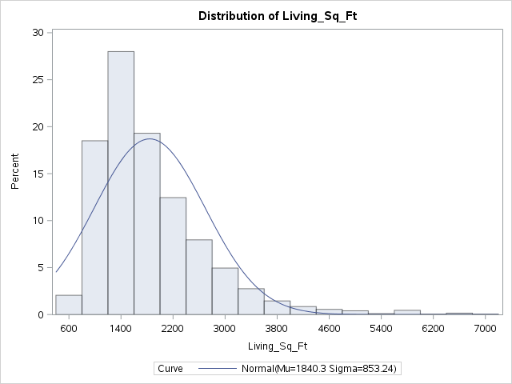

The UNIVARIATE Procedure

Fitted Normal Distribution for Living_Sq_Ft

| Parameters for Normal Distribution Parameter | Parameters for Normal Distribution Symbol | Parameters for Normal Distribution Estimate |
| --- | --- | --- |
| Mean | Mu | 1840.32 |
| Std Dev | Sigma | 853.235 |

| Goodness-of-Fit Tests for Normal Distribution Test | Goodness-of-Fit Tests for Normal Distribution Statistic | Goodness-of-Fit Tests for Normal Distribution Statistic | Goodness-of-Fit Tests for Normal Distribution p Value | Goodness-of-Fit Tests for Normal Distribution p Value |
| --- | --- | --- | --- | --- |
| Kolmogorov-Smirnov | D | 0.1094403 | Pr > D | <0.010 |
| Cramer-von Mises | W-Sq | 10.0771813 | Pr > W-Sq | <0.005 |
| Anderson-Darling | A-Sq | 59.7937631 | Pr > A-Sq | <0.005 |

| Quantiles for Normal Distribution Percent | Quantiles for Normal Distribution Quantile Observed | Quantiles for Normal Distribution Quantile Estimated |
| --- | --- | --- |
| 1.0 | 704.000 | -144.601 |
| 5.0 | 904.500 | 436.873 |
| 10.0 | 1019.000 | 746.855 |
| 25.0 | 1250.000 | 1264.822 |
| 50.0 | 1625.000 | 1840.320 |
| 75.0 | 2194.500 | 2415.818 |
| 90.0 | 2938.000 | 2933.785 |
| 95.0 | 3423.500 | 3243.767 |
| 99.0 | 4838.500 | 3825.241 |

```sas
PROC UNIVARIATE DATA=housing noprint;
    VAR LIVING_SQ_FT;
    HISTOGRAM LIVING_SQ_FT / Normal; * Normal creates a normal curve;
RUN;
```

The UNIVARIATE Procedure

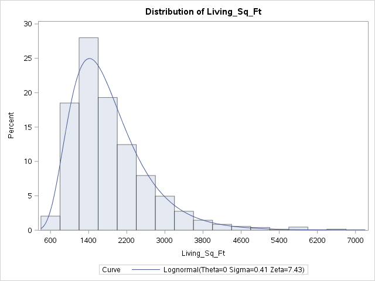

The UNIVARIATE Procedure

Fitted Lognormal Distribution for Living_Sq_Ft

| Parameters for Lognormal Distribution Parameter | Parameters for Lognormal Distribution Symbol | Parameters for Lognormal Distribution Estimate |
| --- | --- | --- |
| Threshold | Theta | 0 |
| Scale | Zeta | 7.428118 |
| Shape | Sigma | 0.413559 |
| Mean |  | 1832.862 |
| Std Dev |  | 791.5927 |

| Goodness-of-Fit Tests for Lognormal Distribution Test | Goodness-of-Fit Tests for Lognormal Distribution Statistic | Goodness-of-Fit Tests for Lognormal Distribution Statistic | Goodness-of-Fit Tests for Lognormal Distribution p Value | Goodness-of-Fit Tests for Lognormal Distribution p Value |
| --- | --- | --- | --- | --- |
| Kolmogorov-Smirnov | D | 0.03801564 | Pr > D | <0.010 |
| Cramer-von Mises | W-Sq | 0.71048795 | Pr > W-Sq | <0.005 |
| Anderson-Darling | A-Sq | 4.20760256 | Pr > A-Sq | <0.005 |

| Quantiles for Lognormal Distribution Percent | Quantiles for Lognormal Distribution Quantile Observed | Quantiles for Lognormal Distribution Quantile Estimated |
| --- | --- | --- |
| 1.0 | 704.000 | 642.930 |
| 5.0 | 904.500 | 852.245 |
| 10.0 | 1019.000 | 990.412 |
| 25.0 | 1250.000 | 1273.057 |
| 50.0 | 1625.000 | 1682.638 |
| 75.0 | 2194.500 | 2223.994 |
| 90.0 | 2938.000 | 2858.682 |
| 95.0 | 3423.500 | 3322.135 |
| 99.0 | 4838.500 | 4403.704 |

```sas
PROC UNIVARIATE DATA=housing noprint;
    VAR LIVING_SQ_FT;
    HISTOGRAM LIVING_SQ_FT / Lognormal; * Normal creates a normal curve;
RUN;
```

#### Additional Options for PROC MEANS

In addition the options outlined earlier, here are a few more options built into PROC MEANS.

- CLM (two-sided confidence limits)
- P1 (1 percent quantile)
- p10 (10 percent quantile)
- CV (coefficient of variation)
- LCLM (lower confidence limit)
- UCLM (upper confidence limit)

#### PROC TTEST

Q: Describe a t-test and give an example of when it might be used (ideally in the context of one of the data sets we have seen in this course).

##### One Sample Comparison

This is useful to test whether the mean is significantly different from a hypothesis $H_0$ value of *n*.

```
PROC TTEST DATA=yourdata H0 = n options;
    VAR variable;
RUN;
```

Options include:

- ALPHA = n (alpha level, default is 0.05)
- H0 = n (requests a test of $H_0=n$, default value is 0)
- SIDES = type (options are 2, the default, and L for lower one-sided, and U for upper one-sided)

The TTEST Procedure

Variable: Living_Sq_Ft

| N | Mean | Std Dev | Std Err | Minimum | Maximum |
| --- | --- | --- | --- | --- | --- |
| 2000 | 1840.3 | 853.2 | 19.0789 | 488.0 | 6963.0 |

| Mean | 95% CL Mean |  | Std Dev | 95% CL Std Dev |  |
| --- | --- | --- | --- | --- | --- |
| 1840.3 | 1802.9 | 1877.7 | 853.2 | 827.6 | 880.5 |

| DF | t Value | Pr > \|t\| |
| --- | --- | --- |
| 1999 | -34.58 | <.0001 |

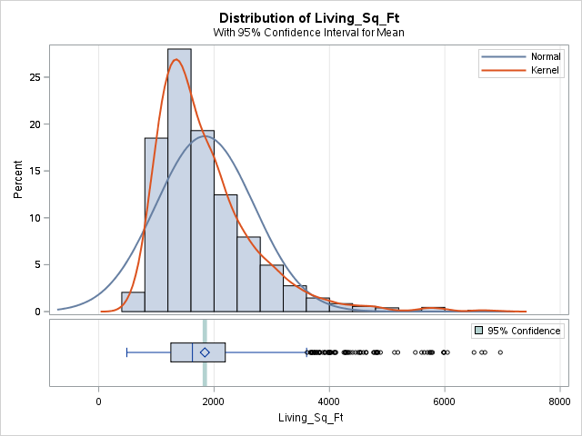

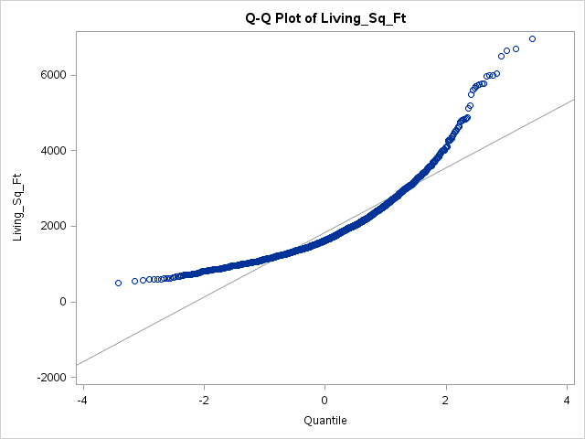

```sas
PROC TTEST DATA=HOUSING H0 = 2500;
    VAR LIVING_SQ_FT;
RUN;
```

#### Two independent sample comparisons

To compare differences between two groups use this procedure:

```
PROC TTEST DATA=yourdata options;
    CLASS variable;
    VAR variable;
RUN;
```

Class is the categorical variable that you like to test differences.

The TTEST Procedure

Variable: Closing_Price

| State | N | Mean | Std Dev | Std Err | Minimum | Maximum |
| --- | --- | --- | --- | --- | --- | --- |
| CO | 80 | 716647 | 1196747 | 133800 | 52000.0 | 7650000 |
| VA | 80 | 281179 | 182367 | 20389.3 | 40000.0 | 1075000 |
| Diff (1-2) |  | 435468 | 855997 | 135345 |  |  |

| State | Method | Mean | 95% CL Mean |  | Std Dev | 95% CL Std Dev |  |
| --- | --- | --- | --- | --- | --- | --- | --- |
| CO |  | 716647 | 450324 | 982970 | 1196747 | 1035728 | 1417514 |
| VA |  | 281179 | 240595 | 321763 | 182367 | 157830 | 216009 |
| Diff (1-2) | Pooled | 435468 | 168149 | 702787 | 855997 | 771122 | 962032 |
| Diff (1-2) | Satterthwaite | 435468 | 166256 | 704680 |  |  |  |

| Method | Variances | DF | t Value | Pr > \|t\| |
| --- | --- | --- | --- | --- |
| Pooled | Equal | 158 | 3.22 | 0.0016 |
| Satterthwaite | Unequal | 82.667 | 3.22 | 0.0018 |

| Equality of Variances Method | Equality of Variances Num DF | Equality of Variances Den DF | Equality of Variances F Value | Equality of Variances Pr > F |
| --- | --- | --- | --- | --- |
| Folded F | 79 | 79 | 43.06 | <.0001 |

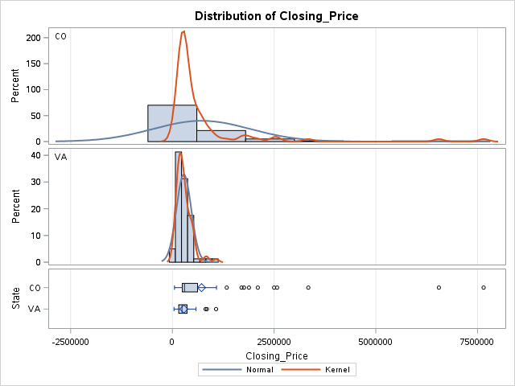

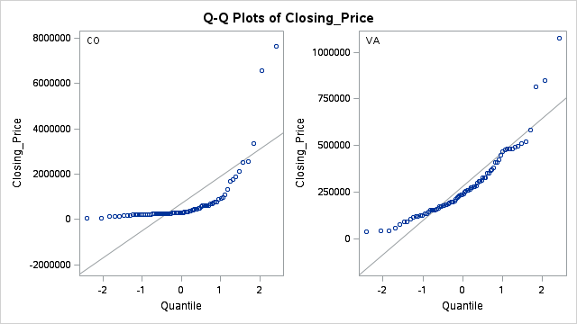

```sas
PROC TTEST DATA=VA_CO;
    CLASS State;
    VAR Closing_Price;
RUN;
```

### Paired t-test

Another type of t-test involves paired data.

```
PROC TTEST DATA=yourdata options;
    PAIRED variable1 * variable2;
RUN;
```

#### PROC TTEST GRAPHICS

The ttest procedure automatically creates a few graphics, but that can be controlled using the following syntax.

```
PROC TTEST DATA=yourdata PLOTS = (plot-request)
```

The plot requests are:

- ALL (produce all plots)
- BOXPLOT (creates box plots)
- HISTOGRAM
- INTERVALPLOT (creates plots of confidence interval of means)
- NONE (suppresses all plots)
- QQPLOT
- SUMMARYPLOT (creates one plot that contains histrograms and box plots)

### Exercise 3: Proc Univariate

1. Use Proc Univariate to summarize the registered and casual variables in the bikes dataset.
2. Include a histogram with a normal density superimposed.
3. Does the normal density match the data? Why or why not?

The UNIVARIATE Procedure

Variable: registered

| Moments |  |  |  |
| --- | --- | --- | --- |
| N | 10886 | Sum Weights | 10886 |
| Mean | 155.552177 | Sum Observations | 1693341 |
| Std Deviation | 151.039033 | Variance | 22812.7895 |
| Skewness | 1.52480459 | Kurtosis | 2.626081 |
| Uncorrected SS | 511720093 | Corrected SS | 248317214 |
| Coeff Variation | 97.0986301 | Std Error Mean | 1.44762152 |

| Basic Statistical Measures Location | Basic Statistical Measures Location | Basic Statistical Measures Variability | Basic Statistical Measures Variability |
| --- | --- | --- | --- |
| Mean | 155.5522 | Std Deviation | 151.03903 |
| Median | 118.0000 | Variance | 22813 |
| Mode | 3.0000 | Range | 886.00000 |
|  |  | Interquartile Range | 186.00000 |

| Tests for Location: Mu0=0 Test | Tests for Location: Mu0=0 Statistic | Tests for Location: Mu0=0 Statistic | Tests for Location: Mu0=0 p Value | Tests for Location: Mu0=0 p Value |
| --- | --- | --- | --- | --- |
| Student's t | t | 107.4536 | Pr > \|t\| | <.0001 |
| Sign | M | 5435.5 | Pr >= \|M\| | <.0001 |
| Signed Rank | S | 29547378 | Pr >= \|S\| | <.0001 |

| Quantiles (Definition 5) Level | Quantiles (Definition 5) Quantile |
| --- | --- |
| 100% Max | 886 |
| 99% | 697 |
| 95% | 464 |
| 90% | 354 |
| 75% Q3 | 222 |
| 50% Median | 118 |
| 25% Q1 | 36 |
| 10% | 7 |
| 5% | 4 |
| 1% | 1 |
| 0% Min | 0 |

| Extreme Observations Lowest Value | Extreme Observations Lowest Obs | Extreme Observations Highest Value | Extreme Observations Highest Obs |
| --- | --- | --- | --- |
| 0 | 4012 | 833 | 9585 |
| 0 | 3890 | 839 | 9897 |
| 0 | 3867 | 857 | 9298 |
| 0 | 3725 | 857 | 9753 |
| 0 | 3318 | 886 | 9346 |

The UNIVARIATE Procedure

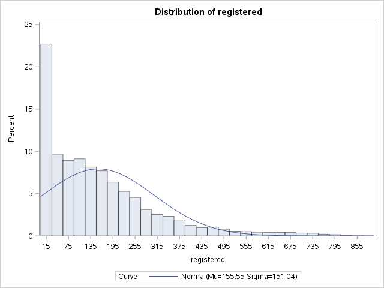

The UNIVARIATE Procedure

Fitted Normal Distribution for registered

| Parameters for Normal Distribution Parameter | Parameters for Normal Distribution Symbol | Parameters for Normal Distribution Estimate |
| --- | --- | --- |
| Mean | Mu | 155.5522 |
| Std Dev | Sigma | 151.039 |

| Goodness-of-Fit Tests for Normal Distribution Test | Goodness-of-Fit Tests for Normal Distribution Statistic | Goodness-of-Fit Tests for Normal Distribution Statistic | Goodness-of-Fit Tests for Normal Distribution p Value | Goodness-of-Fit Tests for Normal Distribution p Value |
| --- | --- | --- | --- | --- |
| Kolmogorov-Smirnov | D | 0.151715 | Pr > D | <0.010 |
| Cramer-von Mises | W-Sq | 59.670109 | Pr > W-Sq | <0.005 |
| Anderson-Darling | A-Sq | 383.449398 | Pr > A-Sq | <0.005 |

| Quantiles for Normal Distribution Percent | Quantiles for Normal Distribution Quantile Observed | Quantiles for Normal Distribution Quantile Estimated |
| --- | --- | --- |
| 1.0 | 1.00000 | -195.8172 |
| 5.0 | 4.00000 | -92.8849 |
| 10.0 | 7.00000 | -38.0121 |
| 25.0 | 36.00000 | 53.6779 |
| 50.0 | 118.00000 | 155.5522 |
| 75.0 | 222.00000 | 257.4265 |
| 90.0 | 354.00000 | 349.1165 |
| 95.0 | 464.00000 | 403.9893 |
| 99.0 | 697.00000 | 506.9215 |

The UNIVARIATE Procedure

Variable: casual

| Moments |  |  |  |
| --- | --- | --- | --- |
| N | 10886 | Sum Weights | 10886 |
| Mean | 36.0219548 | Sum Observations | 392135 |
| Std Deviation | 49.9604766 | Variance | 2496.04922 |
| Skewness | 2.4957484 | Kurtosis | 7.55162931 |
| Uncorrected SS | 41294965 | Corrected SS | 27169495.8 |
| Coeff Variation | 138.694518 | Std Error Mean | 0.47884219 |

| Basic Statistical Measures Location | Basic Statistical Measures Location | Basic Statistical Measures Variability | Basic Statistical Measures Variability |
| --- | --- | --- | --- |
| Mean | 36.02195 | Std Deviation | 49.96048 |
| Median | 17.00000 | Variance | 2496 |
| Mode | 0.00000 | Range | 367.00000 |
|  |  | Interquartile Range | 45.00000 |

| Tests for Location: Mu0=0 Test | Tests for Location: Mu0=0 Statistic | Tests for Location: Mu0=0 Statistic | Tests for Location: Mu0=0 p Value | Tests for Location: Mu0=0 p Value |
| --- | --- | --- | --- | --- |
| Student's t | t | 75.2272 | Pr > \|t\| | <.0001 |
| Sign | M | 4950 | Pr >= \|M\| | <.0001 |
| Signed Rank | S | 24504975 | Pr >= \|S\| | <.0001 |

| Quantiles (Definition 5) Level | Quantiles (Definition 5) Quantile |
| --- | --- |
| 100% Max | 367 |
| 99% | 241 |
| 95% | 141 |
| 90% | 94 |
| 75% Q3 | 49 |
| 50% Median | 17 |
| 25% Q1 | 4 |
| 10% | 1 |
| 5% | 0 |
| 1% | 0 |
| 0% Min | 0 |

| Extreme Observations Lowest Value | Extreme Observations Lowest Obs | Extreme Observations Highest Value | Extreme Observations Highest Obs |
| --- | --- | --- | --- |
| 0 | 10866 | 356 | 7687 |
| 0 | 10844 | 357 | 6729 |
| 0 | 10842 | 361 | 7686 |
| 0 | 10840 | 362 | 9652 |
| 0 | 10839 | 367 | 6730 |

The UNIVARIATE Procedure

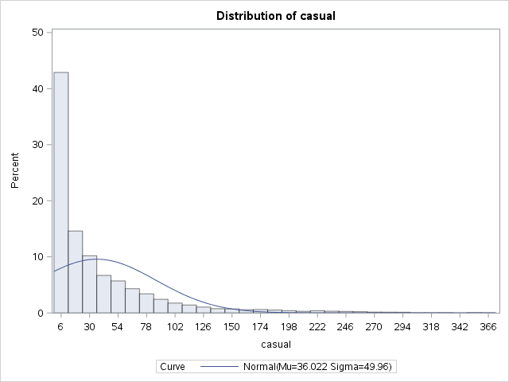

The UNIVARIATE Procedure

Fitted Normal Distribution for casual

| Parameters for Normal Distribution Parameter | Parameters for Normal Distribution Symbol | Parameters for Normal Distribution Estimate |
| --- | --- | --- |
| Mean | Mu | 36.02195 |
| Std Dev | Sigma | 49.96048 |

| Goodness-of-Fit Tests for Normal Distribution Test | Goodness-of-Fit Tests for Normal Distribution Statistic | Goodness-of-Fit Tests for Normal Distribution Statistic | Goodness-of-Fit Tests for Normal Distribution p Value | Goodness-of-Fit Tests for Normal Distribution p Value |
| --- | --- | --- | --- | --- |
| Kolmogorov-Smirnov | D | 0.235452 | Pr > D | <0.010 |
| Cramer-von Mises | W-Sq | 171.574837 | Pr > W-Sq | <0.005 |
| Anderson-Darling | A-Sq | 948.029130 | Pr > A-Sq | <0.005 |

| Quantiles for Normal Distribution Percent | Quantiles for Normal Distribution Quantile Observed | Quantiles for Normal Distribution Quantile Estimated |
| --- | --- | --- |
| 1.0 | 0.000 | -80.20349 |
| 5.0 | 0.000 | -46.15572 |
| 10.0 | 1.000 | -28.00497 |
| 25.0 | 4.000 | 2.32413 |
| 50.0 | 17.000 | 36.02195 |
| 75.0 | 49.000 | 69.71978 |
| 90.0 | 94.000 | 100.04888 |
| 95.0 | 141.000 | 118.19963 |
| 99.0 | 241.000 | 152.24740 |

```sas
Proc Univariate Data = mydata.bikes;
	Var Registered Casual;
	HISTOGRAM Registered Casual / Normal; * Normal creates a normal curve;
run;
```

### PROC REG

Similar to `lm()` in R, we can also easily run regression in SAS.

```
PROC REG DATA=yourdata;
    MODEL dependent = independent;
RUN;
```

Note including categorical variables can take a bit of extra work to create dummy variables (or use PROC GLM).

The REG Procedure

Model: MODEL1

Dependent Variable: Closing_Price

| Number of Observations Read | 2000 |
| --- | --- |
| Number of Observations Used | 2000 |

| Analysis of Variance Source | Analysis of Variance DF | Analysis of Variance Sum of Squares | Analysis of Variance Mean Square | Analysis of Variance F Value | Analysis of Variance Pr > F |
| --- | --- | --- | --- | --- | --- |
| Model | 1 | 3.287656E13 | 3.287656E13 | 384.41 | <.0001 |
| Error | 1998 | 1.708798E14 | 85525443800 |  |  |
| Corrected Total | 1999 | 2.037564E14 |  |  |  |

| Root MSE | 292447 | R-Square | 0.1614 |
| --- | --- | --- | --- |
| Dependent Mean | 244147 | Adj R-Sq | 0.1609 |
| Coeff Var | 119.78344 |  |  |

| Parameter Estimates Variable | Parameter Estimates DF | Parameter Estimates Parameter Estimate | Parameter Estimates Standard Error | Parameter Estimates t Value | Parameter Estimates Pr > \|t\| |
| --- | --- | --- | --- | --- | --- |
| Intercept | 1 | -32459 | 15550 | -2.09 | 0.0370 |
| Living_Sq_Ft | 1 | 150.30316 | 7.66607 | 19.61 | <.0001 |

The REG Procedure

Model: MODEL1

Dependent Variable: Closing_Price

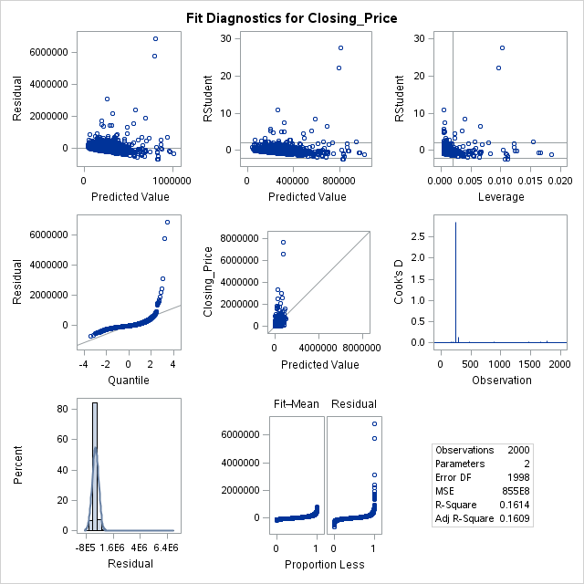

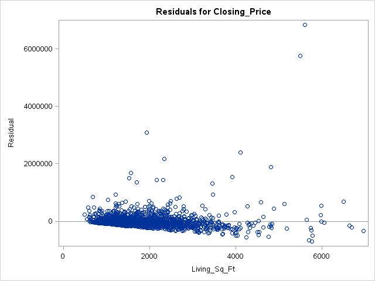

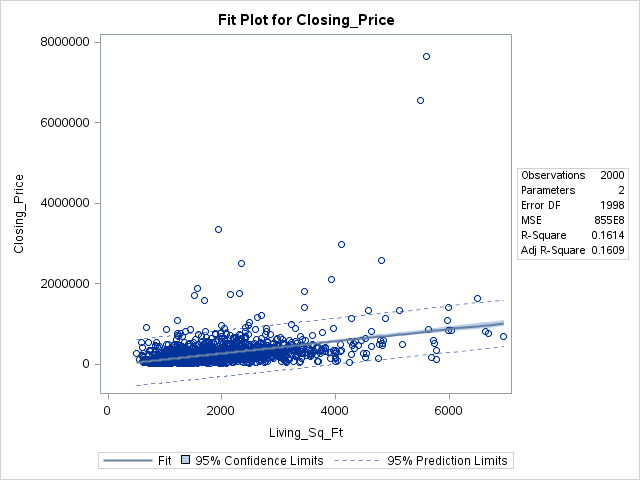

```sas
PROC REG DATA=housing;
    MODEL CLOSING_PRICE = LIVING_SQ_FT;
RUN;
```

#### PROC REG GRAPHICS

Graphics can easily be created from PROC REG using the following syntax:

```
PROC REG DATA=yourdata PLOTS(options) = (plot request list);
    MODEL dependent = independent;
RUN;
```

For the options trailing PLOTS use (ONLY) if you wish to omit the default plots.

Plot requests

- FITPLOT (scatter plot with regression line and confidence bands)
- RESIDUALS ( residuals plotted against independent variables)
- DIAGNOSTICS (diagnostics panel)
- COOKSD (Cook's D statistic)
- OBSERVEDBYPREDICTED (dependent variable by predicted)
- QQPLOT
- RESIDUALBYPREDICTED
- RESIDUALHISTOGRAM
- RFPLOT (residual fit plot)

The REG Procedure

Model: MODEL1

Dependent Variable: Closing_Price

| Number of Observations Read | 2000 |
| --- | --- |
| Number of Observations Used | 2000 |

| Analysis of Variance Source | Analysis of Variance DF | Analysis of Variance Sum of Squares | Analysis of Variance Mean Square | Analysis of Variance F Value | Analysis of Variance Pr > F |
| --- | --- | --- | --- | --- | --- |
| Model | 1 | 3.287656E13 | 3.287656E13 | 384.41 | <.0001 |
| Error | 1998 | 1.708798E14 | 85525443800 |  |  |
| Corrected Total | 1999 | 2.037564E14 |  |  |  |

| Root MSE | 292447 | R-Square | 0.1614 |
| --- | --- | --- | --- |
| Dependent Mean | 244147 | Adj R-Sq | 0.1609 |
| Coeff Var | 119.78344 |  |  |

| Parameter Estimates Variable | Parameter Estimates DF | Parameter Estimates Parameter Estimate | Parameter Estimates Standard Error | Parameter Estimates t Value | Parameter Estimates Pr > \|t\| |
| --- | --- | --- | --- | --- | --- |
| Intercept | 1 | -32459 | 15550 | -2.09 | 0.0370 |
| Living_Sq_Ft | 1 | 150.30316 | 7.66607 | 19.61 | <.0001 |

The REG Procedure

Model: MODEL1

Dependent Variable: Closing_Price

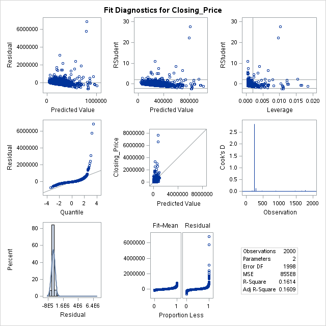

```sas
PROC REG DATA=housing PLOTS(ONLY) = DIAGNOSTICS;
    MODEL CLOSING_PRICE = LIVING_SQ_FT;
RUN;
```

### PROC ANOVA

This procedure allows you to run an analysis of variance procedure with the following syntax:

```
PROC ANOVA DATA =yourdata;
    CLASS classvariable;
    MODEL dependent = effects;
RUN;
```

```sas
DATA ANDYLIVED;
    SET HOUSING;
    IF STATE in ('IA', 'MT','CO','MN','CA','VA');
RUN;
```

The ANOVA Procedure

| Class Level Information Class | Class Level Information Levels | Class Level Information Values |
| --- | --- | --- |
| State | 6 | CA CO IA MN MT VA |

| Number of Observations Read | 440 |
| --- | --- |
| Number of Observations Used | 440 |

The ANOVA Procedure

Dependent Variable: Closing_Price

| Source | DF | Sum of Squares | Mean Square | F Value | Pr > F |
| --- | --- | --- | --- | --- | --- |
| Model | 5 | 1.43091E13 | 2.8618199E12 | 9.81 | <.0001 |
| Error | 434 | 1.2654988E14 | 291589585117 |  |  |
| Corrected Total | 439 | 1.4085898E14 |  |  |  |

| R-Square | Coeff Var | Root MSE | Closing_Price Mean |
| --- | --- | --- | --- |
| 0.101585 | 143.7899 | 539990.4 | 375541.3 |

| Source | DF | Anova SS | Mean Square | F Value | Pr > F |
| --- | --- | --- | --- | --- | --- |
| State | 5 | 1.43091E13 | 2.8618199E12 | 9.81 | <.0001 |

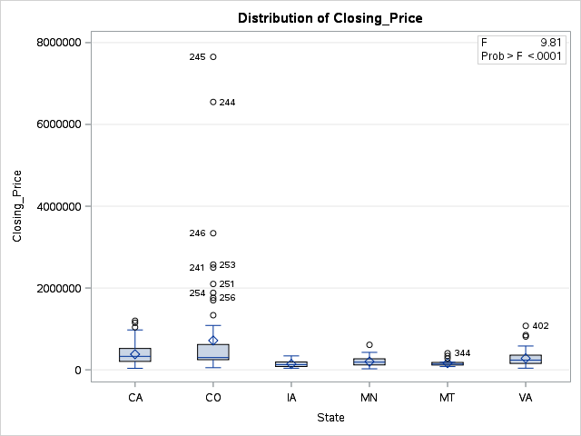

```sas
PROC ANOVA DATA=ANDYLIVED;
    CLASS STATE;
    MODEL CLOSING_PRICE = STATE;
RUN;
```

### Exercise 4: Proc Reg / Anova

1. Using the bikes dataset fit a regression model to predict the count of bikes.
2. What is the best adjusted - R-squared value you can acheive? (without using casual and registered).
3. Does the model treat season correctly?

The REG Procedure

Model: MODEL1

Dependent Variable: count

| Number of Observations Read | 10886 |
| --- | --- |
| Number of Observations Used | 10886 |

| Analysis of Variance Source | Analysis of Variance DF | Analysis of Variance Sum of Squares | Analysis of Variance Mean Square | Analysis of Variance F Value | Analysis of Variance Pr > F |
| --- | --- | --- | --- | --- | --- |
| Model | 5 | 61261467 | 12252293 | 450.49 | <.0001 |
| Error | 10880 | 295911447 | 27198 |  |  |
| Corrected Total | 10885 | 357172914 |  |  |  |

| Root MSE | 164.91738 | R-Square | 0.1715 |
| --- | --- | --- | --- |
| Dependent Mean | 191.57413 | Adj R-Sq | 0.1711 |
| Coeff Var | 86.08541 |  |  |

| Parameter Estimates Variable | Parameter Estimates DF | Parameter Estimates Parameter Estimate | Parameter Estimates Standard Error | Parameter Estimates t Value | Parameter Estimates Pr > \|t\| |
| --- | --- | --- | --- | --- | --- |
| Intercept | 1 | 32.97402 | 6.68752 | 4.93 | <.0001 |
| season | 1 | 11.16378 | 1.46727 | 7.61 | <.0001 |
| holiday | 1 | -8.24676 | 9.80449 | -0.84 | 0.4003 |
| temp | 1 | 8.61542 | 0.21053 | 40.92 | <.0001 |
| workingday | 1 | 1.09982 | 3.50658 | 0.31 | 0.7538 |
| weather | 1 | -31.15689 | 2.49998 | -12.46 | <.0001 |

The REG Procedure

Model: MODEL1

Dependent Variable: count

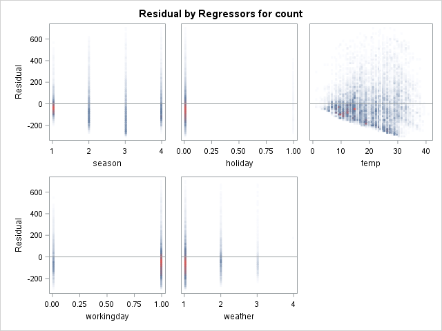

```sas
Proc REG Data = mydata.bikes;
	MODEL Count = season holiday temp workingday weather;
RUN;
```